# SML201 Chapter 2.4

Graphing with the `ggplot2` package

Daisy Huang

Fall 2019

# R functions covered

- Functions in the `ggplot2` package
- `ggpairs()` in the `GGally` package

# Introduction

In the last chapter we saw that we can answer very interesting questions about the passengers with plots that compare different groups of the passengers. Unfortunately, for creating more complex graphs R’s basic graphic functions become more verbose; also, personally I think graphs produced by the basic `graphics` functions are not very appealing aesthetically unless you are willing to spending a lot of time on making manual adjustments to the graphs by changing the values of the graphic variables (e.g., we showed you how to make some of these adjustments with `cex`, `cex.main` and `cex.lab` etc. in this week’s precept). When it comes to making complex graphs the packages `ggplot2` and `GGally` (an extension of `ggplot2`) have a lot more advantages over R’s basic `graphics` package.

# About the `ggplot2` package

The package `ggplot2` was built based on the concepts in the *The Grammar of Graphics* by Leland Wilkinson (1999/2005).

The package has a lot of built-in features that make nice graphs and are more suitable for complex large datasets.

# Read in the dataset

```r
t.ship =
  read.csv(file =
  '/Users/billhaarlow/Desktop/SML201/titanic.csv')
```

We should refresh our memory on the properties of the dataset.

```r
class(t.ship)  # this tells me what kind of R object this dataset is
[1] "data.frame"
dim(t.ship)  # 891 rows by 12 columns
[1] 891  12
```

```r
head(t.ship)  # look at the first 6 (by default) rows of an object
```

|  | PassengerId | Survived | Pclass | Name | Sex | Age | SibSp | Parch | Ticket | Fare | Cabin | Embarked |
| --- | --- | --- | --- | --- | --- | --- | --- | --- | --- | --- | --- | --- |
| 1 | 1 | 0 | 3 | Braund, Mr. Owen Harris | male | 22 | 1 | 0 | A/5 21171 | 7.2500 |  | S |
| 2 | 2 | 1 | 1 | Cumings, Mrs. John Bradley (Florence Briggs Thayer) | female | 38 | 1 | 0 | PC 17599 | 71.2833 | C85 | C |
| 3 | 3 | 1 | 3 | Heikkinen, Miss. Laina | female | 26 | 0 | 0 | STON/O2. 3101282 | 7.9250 |  | S |
| 4 | 4 | 1 | 1 | Futrelle, Mrs. Jacques Heath (Lily May Peel) | female | 35 | 1 | 0 | 113803 | 53.1000 | C123 | S |
| 5 | 5 | 0 | 3 | Allen, Mr. William Henry | male | 35 | 0 | 0 | 373450 | 8.0500 |  | S |
| 6 | 6 | 0 | 3 | Moran, Mr. James | male | NA | 0 | 0 | 330877 | 8.4583 |  | Q |

```r
str(t.ship, strict.width = "cut")
'data.frame':   891 obs. of  12 variables:
 $ PassengerId: int  1 2 3 4 5 6 7 8 9 10 ...
 $ Survived   : int  0 1 1 1 0 0 0 0 1 1 ...
 $ Pclass     : int  3 1 3 1 3 3 1 3 3 2 ...
 $ Name       : Factor w/ 891 levels "Abbing, Mr. Anthony",....
 $ Sex        : Factor w/ 2 levels "female","male": 2 1 1 1 2..
 $ Age        : num  22 38 26 35 35 NA 54 2 27 14 ...
 $ SibSp      : int  1 1 0 1 0 0 0 3 0 1 ...
 $ Parch      : int  0 0 0 0 0 0 0 1 2 0 ...
 $ Ticket     : Factor w/ 681 levels "110152","110413",..: 52..
 $ Fare       : num  7.25 71.28 7.92 53.1 8.05 ...
 $ Cabin      : Factor w/ 148 levels "","A10","A14",..: 1 83 ..
 $ Embarked   : Factor w/ 4 levels "","C","Q","S": 4 2 4 4 4 ..
```

# An example of a graph produced by the `ggplot2` package

```r
library(ggplot2)
```

Here is a set of histograms that produced by the `geom_histogram()` function in the `ggplot2` package. Note that if we had to used the basic graphic functions in R to produce this set of plots, we would have to write the code separately for 6 histograms, not to mention that we would also need to write extra lines of code to give different colors to the data points for the people in the survived and deceased groups.

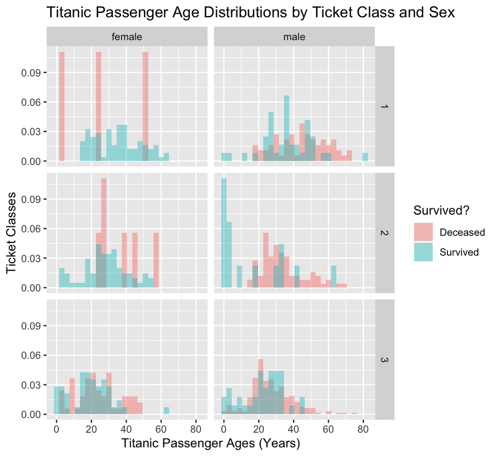

```r
ggplot(t.ship) +
   geom_histogram(mapping = aes(x = Age, y = ..density..,
                                fill = as.factor(Survived)),
                  position="identity", binwidth = 3,
                  alpha = .4) +
  facet_grid(as.factor(Pclass)~Sex) +
  labs(x='Titanic Passenger Ages (Years)',
       y='Ticket Classes',
       title = 'Titanic Passenger Age Distributions by Ticket Class and Sex', fill = "Survived?" ) +
 scale_fill_discrete(labels = c("Deceased", "Survived"))
```